# notebook3saveR

## Ερώτηση 3

imports that we are gonna use , empasize on pd

```python
import pandas as pd
import matplotlib.pyplot as plt
import seaborn as sns
import re
from scipy.stats import ttest_ind
import numpy as np
import json
import ast
import scipy.stats as st
import os
from datetime import datetime, timedelta
from scipy.stats import pearsonr
```

display heads of csv file

```python
csv_data_df = pd.read_csv("Cell_Phones_meta.csv")
print(csv_data_df.head())
print("\n------------------------------------------------------")
print("\n csv Data:", csv_data_df.shape)
```

```
                                            category tech1  \
0  ['Cell Phones & Accessories', 'Cell Phones', '...   NaN
1  ['Cell Phones & Accessories', 'Cell Phones', '...   NaN
2  ['Cell Phones & Accessories', 'Cell Phones', '...   NaN
3  ['Cell Phones & Accessories', 'Cell Phones', '...   NaN
4  ['Cell Phones & Accessories', 'Cell Phones', '...   NaN

                                         description  fit  \
0  ['ICE CENIOR *SENIOR PHONE*, QUAD BAND Super b...  NaN
1  ['Standard package: 1 x original phone 1 x Qua...  NaN
2  ['Dark Blue OEM faceplate, Wall charger and ba...  NaN
3                                                 []  NaN
4  ['Siemens&#146;s SX56 is a combination cell ph...  NaN

                                               title  \
0  UNLOCKED DUAL SIM SLOT *CENIOR PHONE* QUAD BAN...
1                              Nokia 3310 Blue Nokia
2                                Unlocked Nokia 8290
3  Sierra AIRCARD 750 GPRS W/VOICE 1100091, (Unlo...
4  Siemens SX56 - Smartphone - GSM - touch - Wind...

                       also_buy tech2                      brand  \
0                            []   NaN                        Ice
1  ['B075FL4H89', 'B00R25GJJW']   NaN                      Nokia
2                            []   NaN                      Nokia
3                            []   NaN  Sierra Wireless Data Inc.
4                            []   NaN     Siemens Smartphone GSM

                                             feature  \
0  ['2G NETWORK, Quad Band: GSM 850/900/1800/1900...
1  ['GSM 900/1800', 'Simple and elegant', 'Classi...
2  ['Modes GSM 1900, 2-way Text Messaging', 'MMS:...
3                                                 []
4  ['Siemens SX56 - Smartphone - GSM - touch - Wi...

                                                rank  \
0  ['>#6,356,920 in Cell Phones & Accessories (Se...
1  ['>#32,759 in Electronics (See Top 100 in Elec...
2  ['>#6,167,064 in Cell Phones & Accessories (Se...
3  ['>#7,227,749 in Cell Phones & Accessories (Se...
```

[output cut: 25 more lines]

```
1  B00005KBGR  ['https://images-na.ssl-images-amazon.com/imag...
2  B00008KGAG  ['https://images-na.ssl-images-amazon.com/imag...
3  B00009ETU4                                                 []
4  B00009R8S6  ['https://images-na.ssl-images-amazon.com/imag...

                                     imageURLHighRes         last_category
0  ['https://images-na.ssl-images-amazon.com/imag...  Unlocked Cell Phones
1  ['https://images-na.ssl-images-amazon.com/imag...  Unlocked Cell Phones
2  ['https://images-na.ssl-images-amazon.com/imag...  Unlocked Cell Phones
3                                                 []  Unlocked Cell Phones
4  ['https://images-na.ssl-images-amazon.com/imag...  Unlocked Cell Phones

------------------------------------------------------

 csv Data: (8330, 20)
```

display heads of json file

```python
reviews_data_df = pd.read_json("Cell_Phones_and_Accessories_5.json", lines=True)
review_quality = reviews_data_df.copy()
review_quality1 = reviews_data_df.copy()
review_quality2 = reviews_data_df.copy()
print(reviews_data_df.head())
print("\n------------------------------------------------------")
print("Reviews Data:", reviews_data_df.shape)
```

```
   overall  verified   reviewTime      reviewerID        asin  \
0        5      True   08 4, 2014  A24E3SXTC62LJI  7508492919
1        5      True  02 12, 2014  A269FLZCB4GIPV  7508492919
2        3      True   02 8, 2014   AB6CHQWHZW4TV  7508492919
3        2      True   02 4, 2014   A1M117A53LEI8  7508492919
4        4      True   02 3, 2014  A272DUT8M88ZS8  7508492919

                  style      reviewerName  \
0  {'Color:': ' Bling'}  Claudia Valdivia
1                   NaN       sarah ponce
2                   NaN               Kai
3                   NaN   Sharon Williams
4                   NaN   Bella Rodriguez

                                          reviewText  \
0  Looks even better in person. Be careful to not...
1  When you don't want to spend a whole lot of ca...
2  so the case came on time, i love the design. I...
3  DON'T CARE FOR IT.  GAVE IT AS A GIFT AND THEY...
4  I liked it because it was cute, but the studs ...

                               summary  unixReviewTime vote image
0  Can't stop won't stop looking at it      1407110400  NaN   NaN
1                                    1      1392163200  NaN   NaN
2                             Its okay      1391817600  NaN   NaN
3                                 CASE      1391472000  NaN   NaN
4                                Cute!      1391385600  NaN   NaN

------------------------------------------------------
Reviews Data: (1128437, 12)
```

Φορτώστε τα αρχεία αυτά σε pandas dataframes και δουλέψτε με αυτά τα δεδομένα. Τα δεδομένα έχουν θόρυβο, οπότε όταν κοιτάτε κάποιο υποσύνολο των δεδομένων, ή δημιουργείτε κάποια νέα dataframes από τα δεδομένα θα πρέπει να φροντίζεται να αφαιρείτε duplicates, κενές τιμές, κλπ. Υπάρχουν σχετικές μεθόδοι στο Pandas.

Η άσκηση αποτελείται από τα παρακάτω κομμάτια. Ο στόχος είναι να υλοποιήσετε τα παρακάτω χρησιμοποιώντας κατά κύριο λόγο μεθόδους της βιβλιοθήκης Pandas (συν δικές σας συναρτήσεις που θα εφαρμόσετε με apply). Α. Στο κομμάτι αυτό μας ενδιαφέρει να καταλάβουμε την κατανομή που ακολουθεί ο αριθμός των reviews (review count) που έχουν τα προϊόντα (αριθμός διαφορετικών reviewerID που έχουν βαθμολογήσει το κάθε διαφορετικό προϊόν-asin). Χρησιμοποιήστε μεθόδους από Pandas για να υπολογίσετε το review count. Στη συνέχεια, θα κάνετε τις εξής γραφικές παραστάσεις (plots)

1) plot with pandas Ένα ιστόγραμμα του review count με 100 κάδους (bins) χρησιμοποιώντας έτοιμη συνάρτηση της βιβλιοθήκης Panda

```python
reviews_data_df.to_csv("reviews_data.csv", index=False)
reviews_data_df
```

|  | overall | verified | reviewTime | reviewerID | asin | style | reviewerName | reviewText | summary | unixReviewTime | vote | image |
| --- | --- | --- | --- | --- | --- | --- | --- | --- | --- | --- | --- | --- |
| 0 | 5 | True | 08 4, 2014 | A24E3SXTC62LJI | 7508492919 | {'Color:': ' Bling'} | Claudia Valdivia | Looks even better in person. Be careful to not... | Can't stop won't stop looking at it | 1407110400 | NaN | NaN |
| 1 | 5 | True | 02 12, 2014 | A269FLZCB4GIPV | 7508492919 | NaN | sarah ponce | When you don't want to spend a whole lot of ca... | 1 | 1392163200 | NaN | NaN |
| 2 | 3 | True | 02 8, 2014 | AB6CHQWHZW4TV | 7508492919 | NaN | Kai | so the case came on time, i love the design. I... | Its okay | 1391817600 | NaN | NaN |
| 3 | 2 | True | 02 4, 2014 | A1M117A53LEI8 | 7508492919 | NaN | Sharon Williams | DON'T CARE FOR IT. GAVE IT AS A GIFT AND THEY... | CASE | 1391472000 | NaN | NaN |
| 4 | 4 | True | 02 3, 2014 | A272DUT8M88ZS8 | 7508492919 | NaN | Bella Rodriguez | I liked it because it was cute, but the studs ... | Cute! | 1391385600 | NaN | NaN |
| ... | ... | ... | ... | ... | ... | ... | ... | ... | ... | ... | ... | ... |
| 1128432 | 4 | True | 12 22, 2016 | A1QWMCG1FNEP3A | B01HJC7N4C | NaN | Amazon Customer | Good for viewing. But doesn't have a button or... | Good | 1482364800 | NaN | NaN |
| 1128433 | 5 | False | 07 15, 2016 | A3FOBEJ9UVUTR3 | B01HJC7N4C | NaN | David Harlow | I was given the Rockrok 3D VR Glasses Headset ... | THE FUTURE IS NOW!!!!!!! | 1468540800 | NaN | NaN |
| 1128434 | 5 | False | 07 14, 2016 | AMUEAMKB4E33M | B01HJC7N4C | NaN | Tom D | Super Fun! The RockRoc 3d vr headset is waaaay... | Get more out of your smartphone ....... | 1468454400 | NaN | [https://images-na.ssl-images-amazon.com/image... |
| 1128435 | 5 | False | 07 13, 2016 | A2EV91MMOJ3IL4 | B01HJC7N4C | NaN | Timber12 | Love it!\n\nI've had other VR glasses which al... | Join the VR fun train! | 1468368000 | NaN | NaN |
| 1128436 | 5 | True | 05 11, 2017 | ARKQD9Z1VPOV2 | B01HJH9IN6 | NaN | Malfacini | i love it | Five Stars | 1494460800 | NaN | NaN |

1128437 rows × 12 columns

copy new df,group by asin ,remove duplicates at reviewerID,

```
             asin  review_count
0      7508492919            66
1      7532385086            14
2      7887421268            16
3      8199900164             5
4      8288853439            19
...           ...           ...
48181  B01HJBS5C2            18
48182  B01HJC7N4C             7
48183  B01HJCN1UC            30
48184  B01HJCN55I            14
48185  B01HJH9IN6            10

[48186 rows x 2 columns]
```

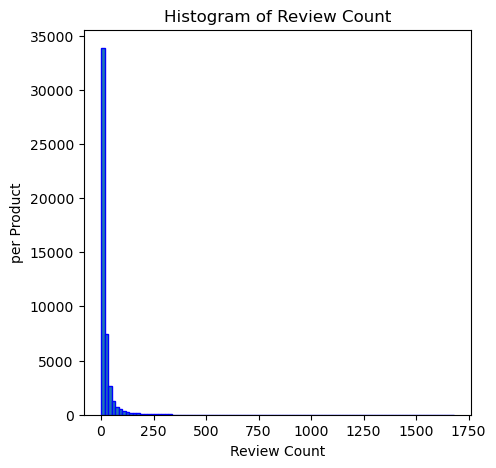

```python
reviews_data_df_1 = pd.DataFrame()
reviews_data_df_1 = reviews_data_df.copy() #for later
reviews_data_df_2 = reviews_data_df.copy()
reviews_data_df_1 = reviews_data_df.groupby('asin')['reviewerID'].nunique().reset_index()

reviews_data_df_1.columns = ['asin', 'review_count']

print(reviews_data_df_1)
reviews_data_df_1['review_count'].plot.hist(bins=100, edgecolor='blue', figsize=(5, 5))
plt.title('Histogram of Review Count')
plt.xlabel('Review Count')
plt.ylabel('per Product')
plt.show()
```

τα περισσότερα προιόντα έχουν λίγα reviews και ένα μικρό σκέλος από αυτά έχουν 50-150 reviews

same with log

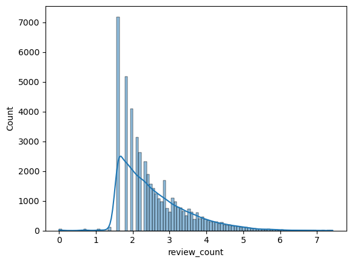

```python
log_reviews_data_df_1 = pd.DataFrame()
log_reviews_data_df_1["review_count"] = np.log(reviews_data_df_1["review_count"])
hist_log = sns.histplot(log_reviews_data_df_1.review_count,bins=100,kde=True)
```

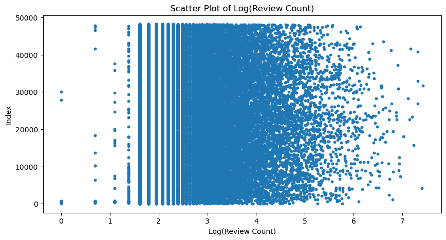

```python
plt.figure(figsize=(10, 5))


plt.scatter(log_reviews_data_df_1["review_count"], log_reviews_data_df_1.index, s=10)


plt.xlabel('Log(Review Count)')
plt.ylabel('Index')
plt.title('Scatter Plot of Log(Review Count)')
plt.show()
```

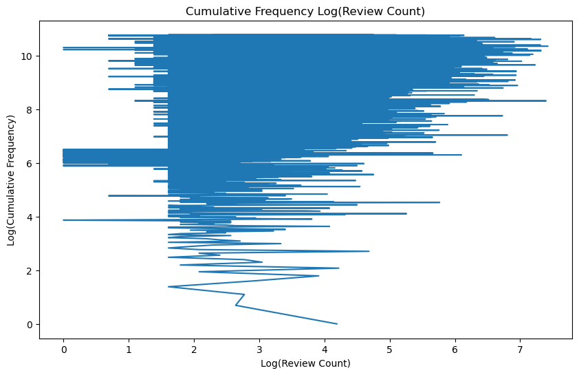

```python
cumulative_freq = np.cumsum(np.ones_like(log_reviews_data_df_1["review_count"]))

plt.figure(figsize=(10, 6))

plt.plot(log_reviews_data_df_1["review_count"], np.log(cumulative_freq), label='Cumulative Frequency')

plt.xlabel('Log(Review Count)')
plt.ylabel('Log(Cumulative Frequency)')
plt.title('Cumulative Frequency Log(Review Count)')
plt.show()
```

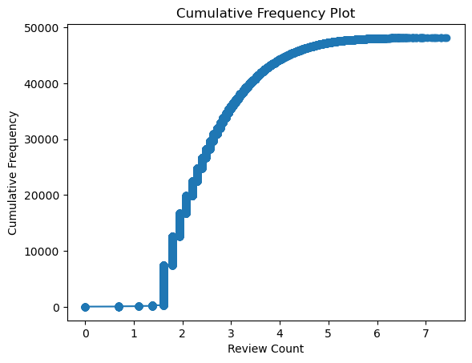

```python
sorted_data = log_reviews_data_df_1['review_count'].sort_values()
cumulative_freq = np.arange(1, len(sorted_data) + 1)
plt.plot(sorted_data, cumulative_freq, marker='o')
plt.xlabel('Review Count')
plt.ylabel('Cumulative Frequency')
plt.title('Cumulative Frequency Plot')
plt.show()
```

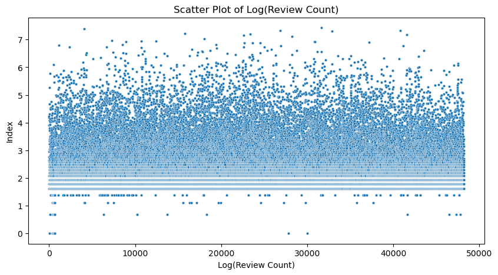

```python
plt.figure(figsize=(10, 5))
scatter_plot = sns.scatterplot(y=log_reviews_data_df_1["review_count"], x=log_reviews_data_df_1.index, s=10)
scatter_plot.set(xlabel='Log(Review Count)', ylabel='Index', title='Scatter Plot of Log(Review Count)')
plt.show()
```

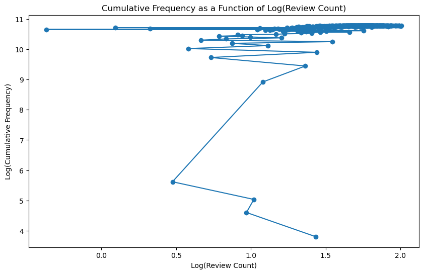

```python
sorted_data = log_reviews_data_df_1['review_count'].sort_values()
log_reviews_data_df_1['sorted_review_count'] = log_reviews_data_df_1['review_count'].sort_values()
frequency = log_reviews_data_df_1['sorted_review_count'].value_counts().sort_index()
cumulative_freq = np.cumsum(frequency)
plt.figure(figsize=(10, 6))
plt.plot(np.log(log_reviews_data_df_1['sorted_review_count'].unique()), np.log(cumulative_freq), marker='o')
plt.xlabel('Log(Review Count)')
plt.ylabel('Log(Cumulative Frequency)')
plt.title('Cumulative Frequency as a Function of Log(Review Count)')

plt.show()
```

Zipf plot

bb

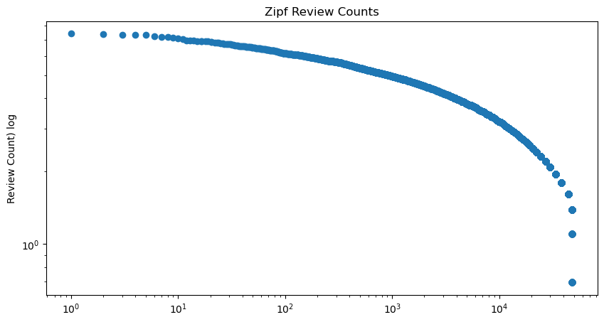

```python
log_reviews_data_df_1['rank'] = log_reviews_data_df_1['review_count'].rank(ascending=False)
plt.figure(figsize=(10, 5))

plt.scatter(log_reviews_data_df_1['rank'], log_reviews_data_df_1['review_count'], marker='o')
plt.xscale('log')
plt.yscale('log')
plt.ylabel('Review Count) log')
plt.title('Zipf Review Counts')
plt.show()
```

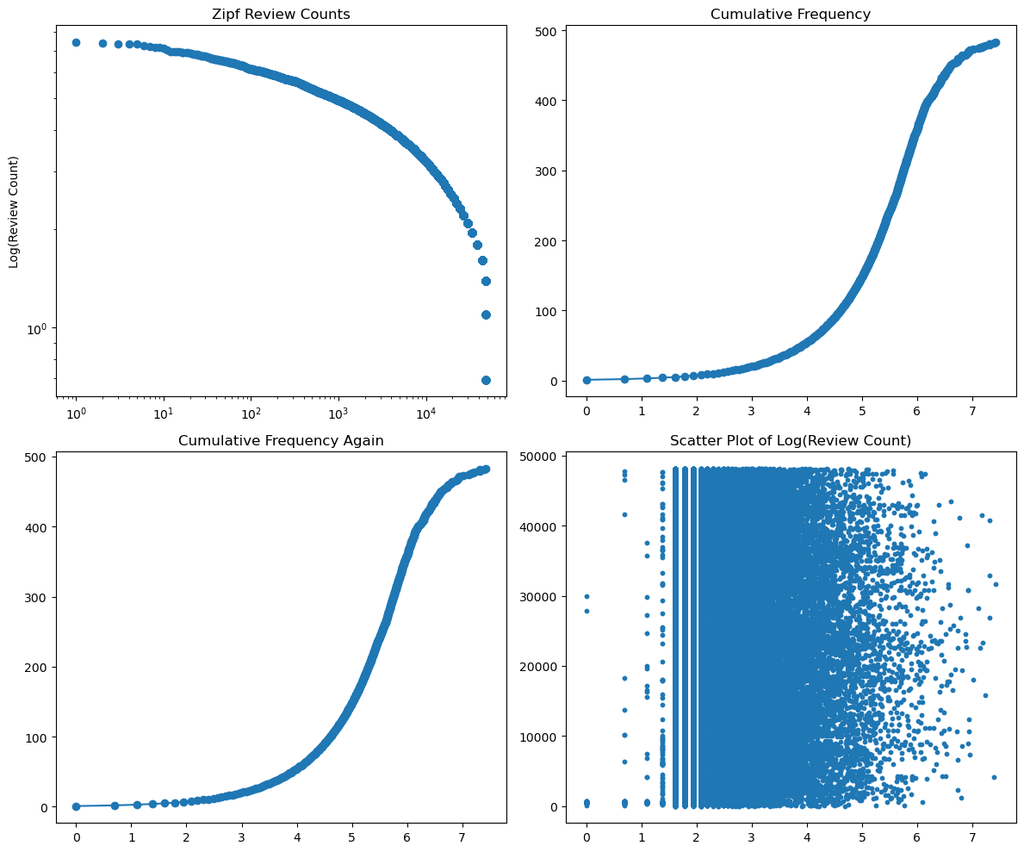

```python
sorted_data = log_reviews_data_df_1['review_count'].sort_values().drop_duplicates()
frequency = sorted_data.value_counts().sort_index()
cumulative_freq = np.cumsum(frequency)

fig, axs = plt.subplots(2, 2, figsize=(12, 10))

axs[0, 0].scatter(log_reviews_data_df_1['rank'], log_reviews_data_df_1['review_count'], marker='o')
axs[0, 0].set_xscale('log')
axs[0, 0].set_yscale('log')
axs[0, 0].set_ylabel('Log(Review Count)')
axs[0, 0].set_title('Zipf Review Counts')

axs[0, 1].plot(sorted_data, cumulative_freq, marker='o')
axs[0, 1].set_title('Cumulative Frequency')

axs[1, 1].scatter(log_reviews_data_df_1["review_count"], log_reviews_data_df_1.index, s=10)
axs[1, 1].set_title('Scatter Plot of Log(Review Count)')

axs[1, 0].plot(sorted_data, cumulative_freq, marker='o')

axs[1, 0].set_title('Cumulative Frequency Again')

plt.tight_layout()
```

## ΕΡΏΤΗΜΑ 3 Β

```python
reviews_data_df.head()
#reviews_data_df = reviews_data_df.drop_duplicates()
```

|  | overall | verified | reviewTime | reviewerID | asin | style | reviewerName | reviewText | summary | unixReviewTime | vote | image |
| --- | --- | --- | --- | --- | --- | --- | --- | --- | --- | --- | --- | --- |
| 0 | 5 | True | 08 4, 2014 | A24E3SXTC62LJI | 7508492919 | {'Color:': ' Bling'} | Claudia Valdivia | Looks even better in person. Be careful to not... | Can't stop won't stop looking at it | 1407110400 | NaN | NaN |
| 1 | 5 | True | 02 12, 2014 | A269FLZCB4GIPV | 7508492919 | NaN | sarah ponce | When you don't want to spend a whole lot of ca... | 1 | 1392163200 | NaN | NaN |
| 2 | 3 | True | 02 8, 2014 | AB6CHQWHZW4TV | 7508492919 | NaN | Kai | so the case came on time, i love the design. I... | Its okay | 1391817600 | NaN | NaN |
| 3 | 2 | True | 02 4, 2014 | A1M117A53LEI8 | 7508492919 | NaN | Sharon Williams | DON'T CARE FOR IT. GAVE IT AS A GIFT AND THEY... | CASE | 1391472000 | NaN | NaN |
| 4 | 4 | True | 02 3, 2014 | A272DUT8M88ZS8 | 7508492919 | NaN | Bella Rodriguez | I liked it because it was cute, but the studs ... | Cute! | 1391385600 | NaN | NaN |

```python
reviews_data_df['unixReviewTime'] = pd.to_datetime(reviews_data_df['unixReviewTime'], unit= 's')
```

```python
reviews_data_df['first_review_per_id'] = reviews_data_df.groupby('reviewerID')['unixReviewTime'].transform('min')
```

```python
reviews_data_df.head()
```

|  | overall | verified | reviewTime | reviewerID | asin | style | reviewerName | reviewText | summary | unixReviewTime | vote | image | first_review_per_id |
| --- | --- | --- | --- | --- | --- | --- | --- | --- | --- | --- | --- | --- | --- |
| 0 | 5 | True | 08 4, 2014 | A24E3SXTC62LJI | 7508492919 | {'Color:': ' Bling'} | Claudia Valdivia | Looks even better in person. Be careful to not... | Can't stop won't stop looking at it | 2014-08-04 | NaN | NaN | 2014-08-04 |
| 1 | 5 | True | 02 12, 2014 | A269FLZCB4GIPV | 7508492919 | NaN | sarah ponce | When you don't want to spend a whole lot of ca... | 1 | 2014-02-12 | NaN | NaN | 2014-02-12 |
| 2 | 3 | True | 02 8, 2014 | AB6CHQWHZW4TV | 7508492919 | NaN | Kai | so the case came on time, i love the design. I... | Its okay | 2014-02-08 | NaN | NaN | 2013-08-30 |
| 3 | 2 | True | 02 4, 2014 | A1M117A53LEI8 | 7508492919 | NaN | Sharon Williams | DON'T CARE FOR IT. GAVE IT AS A GIFT AND THEY... | CASE | 2014-02-04 | NaN | NaN | 2014-02-04 |
| 4 | 4 | True | 02 3, 2014 | A272DUT8M88ZS8 | 7508492919 | NaN | Bella Rodriguez | I liked it because it was cute, but the studs ... | Cute! | 2014-02-03 | NaN | NaN | 2014-02-03 |

```python
reviews_data_df['days_since_first_review'] = (reviews_data_df['unixReviewTime']-reviews_data_df['first_review_per_id']).dt.days
```

```python
reviews_data_df.head()
```

|  | overall | verified | reviewTime | reviewerID | asin | style | reviewerName | reviewText | summary | unixReviewTime | vote | image | first_review_per_id | days_since_first_review |
| --- | --- | --- | --- | --- | --- | --- | --- | --- | --- | --- | --- | --- | --- | --- |
| 0 | 5 | True | 08 4, 2014 | A24E3SXTC62LJI | 7508492919 | {'Color:': ' Bling'} | Claudia Valdivia | Looks even better in person. Be careful to not... | Can't stop won't stop looking at it | 2014-08-04 | NaN | NaN | 2014-08-04 | 0 |
| 1 | 5 | True | 02 12, 2014 | A269FLZCB4GIPV | 7508492919 | NaN | sarah ponce | When you don't want to spend a whole lot of ca... | 1 | 2014-02-12 | NaN | NaN | 2014-02-12 | 0 |
| 2 | 3 | True | 02 8, 2014 | AB6CHQWHZW4TV | 7508492919 | NaN | Kai | so the case came on time, i love the design. I... | Its okay | 2014-02-08 | NaN | NaN | 2013-08-30 | 162 |
| 3 | 2 | True | 02 4, 2014 | A1M117A53LEI8 | 7508492919 | NaN | Sharon Williams | DON'T CARE FOR IT. GAVE IT AS A GIFT AND THEY... | CASE | 2014-02-04 | NaN | NaN | 2014-02-04 | 0 |
| 4 | 4 | True | 02 3, 2014 | A272DUT8M88ZS8 | 7508492919 | NaN | Bella Rodriguez | I liked it because it was cute, but the studs ... | Cute! | 2014-02-03 | NaN | NaN | 2014-02-03 | 0 |

```python
reviews_data_df['month_past'] = reviews_data_df['days_since_first_review'] // 30
reviews_data_df.head()
```

|  | overall | verified | reviewTime | reviewerID | asin | style | reviewerName | reviewText | summary | unixReviewTime | vote | image | first_review_per_id | days_since_first_review | month_past |
| --- | --- | --- | --- | --- | --- | --- | --- | --- | --- | --- | --- | --- | --- | --- | --- |
| 0 | 5 | True | 08 4, 2014 | A24E3SXTC62LJI | 7508492919 | {'Color:': ' Bling'} | Claudia Valdivia | Looks even better in person. Be careful to not... | Can't stop won't stop looking at it | 2014-08-04 | NaN | NaN | 2014-08-04 | 0 | 0 |
| 1 | 5 | True | 02 12, 2014 | A269FLZCB4GIPV | 7508492919 | NaN | sarah ponce | When you don't want to spend a whole lot of ca... | 1 | 2014-02-12 | NaN | NaN | 2014-02-12 | 0 | 0 |
| 2 | 3 | True | 02 8, 2014 | AB6CHQWHZW4TV | 7508492919 | NaN | Kai | so the case came on time, i love the design. I... | Its okay | 2014-02-08 | NaN | NaN | 2013-08-30 | 162 | 5 |
| 3 | 2 | True | 02 4, 2014 | A1M117A53LEI8 | 7508492919 | NaN | Sharon Williams | DON'T CARE FOR IT. GAVE IT AS A GIFT AND THEY... | CASE | 2014-02-04 | NaN | NaN | 2014-02-04 | 0 | 0 |
| 4 | 4 | True | 02 3, 2014 | A272DUT8M88ZS8 | 7508492919 | NaN | Bella Rodriguez | I liked it because it was cute, but the studs ... | Cute! | 2014-02-03 | NaN | NaN | 2014-02-03 | 0 | 0 |

```python
average_rating_per_month = reviews_data_df.groupby('month_past')['overall'].agg(['mean', 'count'])
print(average_rating_per_month)
```

```
                mean   count
month_past
0           4.240438  373206
1           4.322685   35716
2           4.315216   28720
3           4.288620   25764
4           4.275375   24552
...              ...     ...
176         1.000000       1
177         3.666667       3
178         1.000000       1
179         5.000000       1
181         5.000000       1

[179 rows x 2 columns]
```

```python
average_rating_per_month = average_rating_per_month[average_rating_per_month['mean'] >= 2]
display(average_rating_per_month)
```

| month_past | mean | count |
| --- | --- | --- |
| 0 | 4.240438 | 373206 |
| 1 | 4.322685 | 35716 |
| 2 | 4.315216 | 28720 |
| 3 | 4.288620 | 25764 |
| 4 | 4.275375 | 24552 |
| ... | ... | ... |
| 174 | 3.000000 | 1 |
| 175 | 5.000000 | 1 |
| 177 | 3.666667 | 3 |
| 179 | 5.000000 | 1 |
| 181 | 5.000000 | 1 |

177 rows × 2 columns

```python
confidence = 0.95
interval = st.t.interval(confidence, average_rating_per_month['count']-1, loc=average_rating_per_month['mean'], scale=st.sem(average_rating_per_month['mean']))
print(interval)
```

```
(array([4.19828113, 4.28052609, 4.27305711, 4.24646081, 4.23321565,
       4.22858143, 4.19678433, 4.20985168, 4.18921089, 4.20973096,
       4.1903104 , 4.17162791, 4.16485619, 4.17294643, 4.17117431,
       4.15229718, 4.17287806, 4.1583338 , 4.16250961, 4.14489468,
       4.15010861, 4.1532358 , 4.15056223, 4.15968722, 4.15983232,
       4.14415776, 4.14381203, 4.14838487, 4.135877  , 4.13310267,
       4.13972512, 4.12670809, 4.1289773 , 4.16532637, 4.13832574,
       4.08874508, 4.16565485, 4.14203092, 4.09130212, 4.11755031,
       4.13754284, 4.11431855, 4.10073875, 4.13992998, 4.11388929,
       4.13393738, 4.1153592 , 4.1332667 , 4.08565443, 4.1051586 ,
       4.11594691, 4.0918874 , 4.10585624, 4.10068361, 4.17019144,
       4.10689755, 4.06678017, 4.10128967, 4.11144505, 4.12092966,
       4.15170218, 4.07228747, 4.07254529, 4.07859033, 4.14118586,
       4.0407379 , 4.08393077, 4.09139683, 4.08454991, 4.10885792,
       4.07709641, 4.14850394, 4.10442668, 4.06579187, 4.05944395,
       4.08860574, 4.06727418, 4.09980688, 4.12245549, 4.16172247,
       4.03243521, 4.12649093, 4.14558679, 4.1229551 , 3.94791915,
       4.03289257, 4.0712236 , 4.03875716, 4.09923148, 3.95987892,
       4.02021971, 4.02148762, 3.99442114, 4.01686266, 4.13468267,
       4.12041296, 4.15766259, 4.05131658, 3.96757438, 3.9266358 ,
       4.10217323, 4.18146696, 4.00956806, 4.03489658, 4.0167052 ,
       4.07242882, 4.06866716, 3.84258506, 3.95209633, 4.12948794,
       4.04302873, 4.10459777, 4.09514847, 4.00290449, 4.13790408,
       4.15231768, 4.12407657, 4.07814761, 4.11194402, 4.09652115,
       3.96849121, 4.15118802, 4.23432006, 4.01104459, 4.12611561,
       4.22571249, 3.88914832, 4.13886162, 4.3402938 , 4.05117853,
       3.71262612, 4.16506268, 4.22935011, 4.12691727, 4.08799745,
       4.23149381, 4.0249062 , 3.88697517, 3.66383845, 3.68934236,
       4.20498101, 4.24639521, 4.14097267, 3.89906429, 4.09638964,
       4.35134312, 4.22053432, 4.55134312, 4.10698193, 3.95207482,
       4.05134312, 3.95134312, 4.80451208, 3.14028127, 4.32413915,
       4.14028127, 4.36616753, 4.15134312, 3.94913915, 3.34028127,
       3.72817779, 4.28373335,        nan, 4.90745397, 2.93154856,
       3.22670145,        nan,        nan, 4.57412064,        nan,
       3.22670145,        nan,        nan,        nan, 3.57412064,
              nan,        nan]), array([4.28259538, 4.36484293, 4.35737464, 4.33077875, 4.31753378,
       4.31289965, 4.28110287, 4.29417025, 4.27352973, 4.29404976,
       4.27462928, 4.25594686, 4.24917514, 4.25726581, 4.25549379,
       4.23661695, 4.25719781, 4.24265392, 4.24682986, 4.22921503,
       4.23442903, 4.23755656, 4.23488305, 4.24400793, 4.24415307,
```

[output cut: 16 more lines]

```
       4.15723625, 4.15355506, 3.92741494, 4.03697471, 4.21446111,
       4.1280239 , 4.18951987, 4.18021385, 4.0880046 , 4.22299818,
       4.23751283, 4.20925676, 4.16361063, 4.19733433, 4.18173972,
       4.0539807 , 4.23656709, 4.31989681, 4.0964823 , 4.21191256,
       4.31160095, 3.97525846, 4.22477475, 4.42637287, 4.13750071,
       3.799569  , 4.25160399, 4.31610443, 4.21350826, 4.17516045,
       4.31850619, 4.11302483, 3.9750938 , 3.75282822, 3.77732431,
       4.29501899, 4.33424995, 4.2293977 , 3.9898246 , 4.18932465,
       4.44865688, 4.31279902, 4.64865688, 4.20071038, 4.04792518,
       4.14865688, 4.04865688, 4.90977364, 3.25971873, 4.42586085,
       4.25971873, 4.45736188, 4.24865688, 4.05086085, 3.45971873,
       3.82737777, 4.38293332,        nan, 5.09254603, 3.06845144,
       3.77329855,        nan,        nan, 4.75921269,        nan,
       3.77329855,        nan,        nan,        nan, 3.75921269,
              nan,        nan]))
```

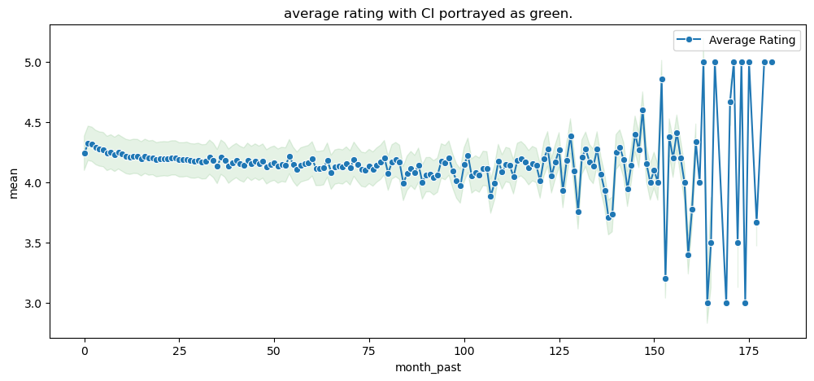

```python
plt.figure(figsize=(12,5),)
sns.lineplot(x=average_rating_per_month.index, y='mean', data=average_rating_per_month, marker='o', label='Average Rating')
plt.fill_between(average_rating_per_month.index, interval[0]-0.1, interval[1]+0.1, color='green',
                 alpha=0.1)
plt.title('average rating with CI portrayed as green.')
plt.show()
```

## ΕΡΏΤΗΜΑ 3Γ

1 ελπίζω να έχω καταλάβει καλά ότι η τιμή overal αντιπροσωπεύει το κάθε review προιόντος ξεχωριστά 2 οτι πρέπει να κοιτάξουμε και στα 2 αρχεία για να βρούμε τα ratings review overal με βάση τα asin

«Όσο πιο ακριβό είναι ένα προϊόν τόσο καλύτερο το μέσο rating του». Για να εξετάσετε την υπόθεση θα πρέπει καταρχάς να εξάγετε μια πραγματική αριθμητική τιμή από τα δεδομένα για την τιμή (price) του προϊόντος. Η στήλη που υπάρχει στα δεδομένα όπως είναι περιέχει πραγματικές τιμές, πραγματικές τιμές με το σύμβολο $ μπροστά, και Strings τα οποία είναι απλά λάθος. Θα πρέπει να βρείτε την πραγματική τιμή για την τιμή του προϊόντος όποτε γίνεται. Αν για το ίδιο asin έχετε πολλές διαφορετικές τιμές, θα πρέπει να το χειριστείτε με κάποιο τρόπο (προσδιορίστε πως). Στη συνέχεια θα πρέπει για κάθε asin να βρείτε το μέσο rating. Μπορείτε να διώξετε προϊόντα που δεν έχουν αρκετά reviews από τα δεδομένα σας.

```python
csv_data_df = pd.read_csv("Cell_Phones_meta.csv")
print(csv_data_df.head())
print("\n------------------------------------------------------")
print("\n csv Data:", csv_data_df.shape)
```

```
                                            category tech1  \
0  ['Cell Phones & Accessories', 'Cell Phones', '...   NaN
1  ['Cell Phones & Accessories', 'Cell Phones', '...   NaN
2  ['Cell Phones & Accessories', 'Cell Phones', '...   NaN
3  ['Cell Phones & Accessories', 'Cell Phones', '...   NaN
4  ['Cell Phones & Accessories', 'Cell Phones', '...   NaN

                                         description  fit  \
0  ['ICE CENIOR *SENIOR PHONE*, QUAD BAND Super b...  NaN
1  ['Standard package: 1 x original phone 1 x Qua...  NaN
2  ['Dark Blue OEM faceplate, Wall charger and ba...  NaN
3                                                 []  NaN
4  ['Siemens&#146;s SX56 is a combination cell ph...  NaN

                                               title  \
0  UNLOCKED DUAL SIM SLOT *CENIOR PHONE* QUAD BAN...
1                              Nokia 3310 Blue Nokia
2                                Unlocked Nokia 8290
3  Sierra AIRCARD 750 GPRS W/VOICE 1100091, (Unlo...
4  Siemens SX56 - Smartphone - GSM - touch - Wind...

                       also_buy tech2                      brand  \
0                            []   NaN                        Ice
1  ['B075FL4H89', 'B00R25GJJW']   NaN                      Nokia
2                            []   NaN                      Nokia
3                            []   NaN  Sierra Wireless Data Inc.
4                            []   NaN     Siemens Smartphone GSM

                                             feature  \
0  ['2G NETWORK, Quad Band: GSM 850/900/1800/1900...
1  ['GSM 900/1800', 'Simple and elegant', 'Classi...
2  ['Modes GSM 1900, 2-way Text Messaging', 'MMS:...
3                                                 []
4  ['Siemens SX56 - Smartphone - GSM - touch - Wi...

                                                rank  \
0  ['>#6,356,920 in Cell Phones & Accessories (Se...
1  ['>#32,759 in Electronics (See Top 100 in Elec...
2  ['>#6,167,064 in Cell Phones & Accessories (Se...
3  ['>#7,227,749 in Cell Phones & Accessories (Se...
```

[output cut: 25 more lines]

```
1  B00005KBGR  ['https://images-na.ssl-images-amazon.com/imag...
2  B00008KGAG  ['https://images-na.ssl-images-amazon.com/imag...
3  B00009ETU4                                                 []
4  B00009R8S6  ['https://images-na.ssl-images-amazon.com/imag...

                                     imageURLHighRes         last_category
0  ['https://images-na.ssl-images-amazon.com/imag...  Unlocked Cell Phones
1  ['https://images-na.ssl-images-amazon.com/imag...  Unlocked Cell Phones
2  ['https://images-na.ssl-images-amazon.com/imag...  Unlocked Cell Phones
3                                                 []  Unlocked Cell Phones
4  ['https://images-na.ssl-images-amazon.com/imag...  Unlocked Cell Phones

------------------------------------------------------

 csv Data: (8330, 20)
```

```python
print(csv_data_df.columns)
print(csv_data_df.dtypes)
```

```
Index(['category', 'tech1', 'description', 'fit', 'title', 'also_buy', 'tech2',
       'brand', 'feature', 'rank', 'also_view', 'details', 'main_cat',
       'similar_item', 'date', 'price', 'asin', 'imageURL', 'imageURLHighRes',
       'last_category'],
      dtype='object')
category            object
tech1               object
description         object
fit                float64
title               object
also_buy            object
tech2               object
brand               object
feature             object
rank                object
also_view           object
details             object
main_cat            object
similar_item        object
date                object
price               object
asin                object
imageURL            object
imageURLHighRes     object
last_category       object
dtype: object
```

```python
csv_data_df = csv_data_df.dropna(subset=['price'])
print(csv_data_df['price'].head(50))
```

```
7                                                 $53.96
20                                                $53.96
44     .a-box-inner{background-color:#fff}#alohaBuyBo...
60     .a-box-inner{background-color:#fff}#alohaBuyBo...
61     .a-box-inner{background-color:#fff}#alohaBuyBo...
64     .a-box-inner{background-color:#fff}#alohaBuyBo...
82                                                $99.99
101                                               $40.08
109                                               $17.99
112                                               $27.57
116                                              $105.99
225                                               $40.08
228                                               $96.36
239                                               $96.34
240                                               $80.23
```

[output cut: 36 more lines]

```python
def is_number(n):
    try:
        float(n)
    except ValueError:
        return False
    return True
# phra afto edw opote TypeError: Could not convert 53.9653.96 to numeric
def clean_price(value):
    if pd.isna(value):
        return None
    try:
        return float(value)
    #RegEx
    except ValueError:
        if isinstance(value, str):
            match = re.search(r'(\d+\.\d+)', value)
            if match:
                return float(match.group(1))
            else:
                return None
        else:
            return None

csv_data_df['price'] = csv_data_df['price'].str.replace('$', '')

csv_data_df = csv_data_df[csv_data_df['price'].apply(is_number)]
csv_data_df['price'] = csv_data_df['price'].apply(clean_price)
csv_data_df = csv_data_df.dropna(subset=['price'])
print(csv_data_df['price'].head(60))
print(csv_data_df['price'].count())
```

```
7       53.96
20      53.96
82      99.99
101     40.08
109     17.99
112     27.57
116    105.99
225     40.08
228     96.36
239     96.34
240     80.23
246     16.00
286     40.08
289     74.98
292     39.95
```

[output cut: 47 more lines]

```python
average_prices = csv_data_df.groupby('asin')['price'].mean()
print(csv_data_df.dtypes)

print(csv_data_df.columns)
print(csv_data_df.dtypes)
print(                  csv_data_df['price'].count())
#xanakanw string
duplicates = csv_data_df['asin'].duplicated()
print(csv_data_df[duplicates])
```

```
category            object
tech1               object
description         object
fit                float64
title               object
also_buy            object
tech2               object
brand               object
feature             object
rank                object
also_view           object
details             object
main_cat            object
similar_item        object
date                object
price              float64
asin                object
imageURL            object
imageURLHighRes     object
last_category       object
dtype: object
Index(['category', 'tech1', 'description', 'fit', 'title', 'also_buy', 'tech2',
       'brand', 'feature', 'rank', 'also_view', 'details', 'main_cat',
       'similar_item', 'date', 'price', 'asin', 'imageURL', 'imageURLHighRes',
       'last_category'],
      dtype='object')
category            object
tech1               object
description         object
fit                float64
title               object
also_buy            object
tech2               object
brand               object
feature             object
rank                object
also_view           object
details             object
main_cat            object
similar_item        object
```

[output cut: 10 more lines]

```

                                          description  fit  \
20  ['Compatible with Sprint cell phone service, t...  NaN

                                              title also_buy tech2  brand  \
20  PCS Vision Picture Phone Nokia PM-6225 (Sprint)       []   NaN  Nokia

   feature                                               rank also_view  \
20      []  ['>#4,250,972 in Cell Phones & Accessories (Se...        []

   details                   main_cat similar_item date  price        asin  \
20      {}  Cell Phones & Accessories          NaN  NaN  53.96  B00023DFSO

   imageURL imageURLHighRes         last_category
20       []              []  Unlocked Cell Phones
```

```python
average_prices_df = csv_data_df.groupby('asin')['price'].mean().reset_index()
print(average_prices_df)

average_prices_df.head()
```

```
            asin   price
0     B00023DFSO   53.96
1     B000CBG95W   99.99
2     B000FJ1XWA   40.08
3     B000FYU4SO   17.99
4     B000G2TLIO   27.57
...          ...     ...
1160  B01HFD0X7Y   27.57
1161  B01HFK15BU  124.99
1162  B01HFK190M   27.57
1163  B01HFKE3HS   75.24
1164  B01HHDLN3A   27.57

[1165 rows x 2 columns]
```

|  | asin | price |
| --- | --- | --- |
| 0 | B00023DFSO | 53.96 |
| 1 | B000CBG95W | 99.99 |
| 2 | B000FJ1XWA | 40.08 |
| 3 | B000FYU4SO | 17.99 |
| 4 | B000G2TLIO | 27.57 |

```python
csv_data_df['price'] = csv_data_df['price'].astype(str)
#to gurnaw se string pali
```

```python
reviews_data_df_2  = pd.read_json("Cell_Phones_and_Accessories_5.json", lines=True)
print(reviews_data_df_2.head())
print(reviews_data_df_2['asin'].count())
```

```
   overall  verified   reviewTime      reviewerID        asin  \
0        5      True   08 4, 2014  A24E3SXTC62LJI  7508492919
1        5      True  02 12, 2014  A269FLZCB4GIPV  7508492919
2        3      True   02 8, 2014   AB6CHQWHZW4TV  7508492919
3        2      True   02 4, 2014   A1M117A53LEI8  7508492919
4        4      True   02 3, 2014  A272DUT8M88ZS8  7508492919

                  style      reviewerName  \
0  {'Color:': ' Bling'}  Claudia Valdivia
1                   NaN       sarah ponce
2                   NaN               Kai
3                   NaN   Sharon Williams
4                   NaN   Bella Rodriguez

                                          reviewText  \
0  Looks even better in person. Be careful to not...
1  When you don't want to spend a whole lot of ca...
2  so the case came on time, i love the design. I...
3  DON'T CARE FOR IT.  GAVE IT AS A GIFT AND THEY...
4  I liked it because it was cute, but the studs ...

                               summary  unixReviewTime vote image
0  Can't stop won't stop looking at it      1407110400  NaN   NaN
1                                    1      1392163200  NaN   NaN
2                             Its okay      1391817600  NaN   NaN
3                                 CASE      1391472000  NaN   NaN
4                                Cute!      1391385600  NaN   NaN
1128437
```

```python
asin_reviewer_counts = reviews_data_df_2.groupby('asin')['reviewerName'].nunique()
asins_with_enough_reviewers = asin_reviewer_counts[asin_reviewer_counts >= 10].index
reviews_data_df_2 = reviews_data_df_2[reviews_data_df_2['asin'].isin(asins_with_enough_reviewers)]
print(reviews_data_df_2.head())
print(reviews_data_df_2['asin'].count())
```

```
   overall  verified   reviewTime      reviewerID        asin  \
0        5      True   08 4, 2014  A24E3SXTC62LJI  7508492919
1        5      True  02 12, 2014  A269FLZCB4GIPV  7508492919
2        3      True   02 8, 2014   AB6CHQWHZW4TV  7508492919
3        2      True   02 4, 2014   A1M117A53LEI8  7508492919
4        4      True   02 3, 2014  A272DUT8M88ZS8  7508492919

                  style      reviewerName  \
0  {'Color:': ' Bling'}  Claudia Valdivia
1                   NaN       sarah ponce
2                   NaN               Kai
3                   NaN   Sharon Williams
4                   NaN   Bella Rodriguez

                                          reviewText  \
0  Looks even better in person. Be careful to not...
1  When you don't want to spend a whole lot of ca...
2  so the case came on time, i love the design. I...
3  DON'T CARE FOR IT.  GAVE IT AS A GIFT AND THEY...
4  I liked it because it was cute, but the studs ...

                               summary  unixReviewTime vote image
0  Can't stop won't stop looking at it      1407110400  NaN   NaN
1                                    1      1392163200  NaN   NaN
2                             Its okay      1391817600  NaN   NaN
3                                 CASE      1391472000  NaN   NaN
4                                Cute!      1391385600  NaN   NaN
980616
```

```python
average_reviews = reviews_data_df_2.groupby('asin')['overall'].mean().reset_index()

asin_price_ratingoverall_df = pd.merge(average_prices_df, average_reviews, on='asin')

print(asin_price_ratingoverall_df)

print(asin_price_ratingoverall_df.columns)
print(asin_price_ratingoverall_df.dtypes)
```

```
           asin   price   overall
0    B000FYU4SO   17.99  3.300000
1    B000G2TLIO   27.57  3.882353
2    B000G7LZCO  105.99  4.181818
3    B0014KLFN6  143.88  4.120000
4    B0016JDBYG   99.00  3.493333
..          ...     ...       ...
357  B01GQWT4SE   27.69  4.043478
358  B01GWUXN5K  224.96  3.888889
359  B01GXAT0BK   40.08  4.320755
360  B01GYLZG6G   27.57  4.000000
361  B01H3V07EW  114.69  4.238095

[362 rows x 3 columns]
Index(['asin', 'price', 'overall'], dtype='object')
asin        object
price      float64
overall    float64
dtype: object
```

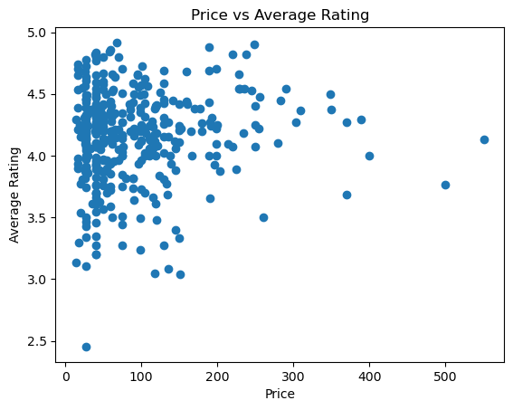

```python
plt.scatter(asin_price_ratingoverall_df['price'], asin_price_ratingoverall_df['overall'])
plt.xlabel('Price')
plt.ylabel('Average Rating')

plt.title('Price vs Average Rating')

plt.show()
```

Το διάγραμμα αυτό δεν μας βοηθάει πολύ . ακολουθεί για τιμές 0 - 100 και 0 - 50

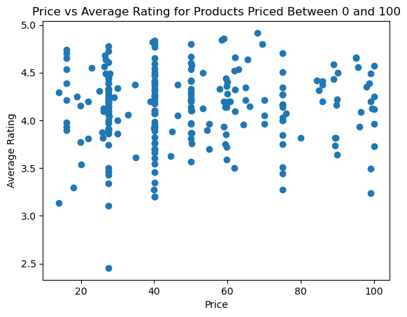

```python
filtered_df = asin_price_ratingoverall_df[asin_price_ratingoverall_df['price'].between(0, 100)]

plt.scatter(filtered_df['price'], filtered_df['overall'])

plt.xlabel('Price')
plt.ylabel('Average Rating')

plt.title('Price vs Average Rating for Products Priced Between 0 and 100')

plt.show()
```

[figure not shown]

```python
filtered_df = asin_price_ratingoverall_df[asin_price_ratingoverall_df['price'].between(0, 50)]

plt.scatter(filtered_df['price'], filtered_df['overall'])

plt.xlabel('Price')
plt.ylabel('Average Rating')

plt.title('Price vs Average Rating for Products Priced Between 0 and 100')

plt.show()
```

```python
corr_coefficient, p_value = np.corrcoef(asin_price_ratingoverall_df['price'], asin_price_ratingoverall_df['overall'])
p_value = pearsonr(asin_price_ratingoverall_df['price'], asin_price_ratingoverall_df['overall'])
print(f"Pearson Correlation Coefficient:{corr_coefficient}")
print(f"P-value: {p_value}")
```

```
Pearson Correlation Coefficient:[1.         0.08357056]
P-value: PearsonRResult(statistic=0.0835705585871459, pvalue=0.1124408921395523)
```

λογαριθμικές αναπαραστάσεις

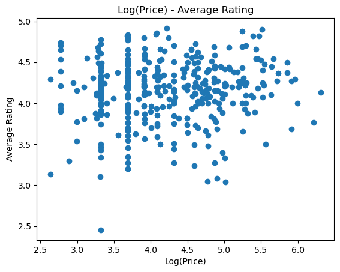

```python
log_price = np.log(asin_price_ratingoverall_df['price'])
plt.scatter(log_price, asin_price_ratingoverall_df['overall'])
plt.xlabel('Log(Price)')
plt.ylabel('Average Rating')
plt.title('Log(Price) - Average Rating')

plt.show()
```

```python
corr_coefficient, p_value = np.corrcoef(np.log(asin_price_ratingoverall_df['price']), asin_price_ratingoverall_df['overall'])
p_value = pearsonr(asin_price_ratingoverall_df['price'], asin_price_ratingoverall_df['overall'])
print(f"Pearson Correlation Coefficient: {corr_coefficient}")
print(f"P-value: {p_value}")
```

```
Pearson Correlation Coefficient: [1.         0.08654134]
P-value: PearsonRResult(statistic=0.0835705585871459, pvalue=0.1124408921395523)
```

[figure not shown]

```python
plt.plot( asin_price_ratingoverall_df['overall'],asin_price_ratingoverall_df['price'])
plt.xlabel('Price')
plt.ylabel('Average Rating')
plt.title('Overall Rating vs Price')

plt.show()
```

## ΕΡΩΤΗΜΑ 3Δ.

1 sτο κομμάτι αυτό θα εξετάσετε αν υπάρχει διαφορά μεταξύ των average ratings που παίρνουν προϊόντα από διαφορετικές μάρκες (brands). 2 Από τα δεδομένα υπολογίστε για κάθε μάρκα τον αριθμό των προϊόντων (asin) που έχει 3 κρατήστε τις πέντε μάρκες με τα περισσότερα προϊόντα 4 Υπολογίστε το average rating των προϊόντων και την μέση τιμή των average ratings για κάθε μάρκα. 5 Ο στόχος μας είναι να εξετάσουν αν υπάρχει στατιστικά σημαντική διαφορά στις μέσες τιμές μεταξύ των διαφορετικών brands. 6 Για το στόχο αυτό δημιουργείστε καταρχάς ένα point plot που θα έχετε την μέση τιμή για κάθε brand και το 95% confidence interval. 7 Προσπαθήστε να εξάγετε κάποιο συμπέρασμα αρχικά από το plot. 8 Στη συνέχεια για κάθε ζευγάρι από brands χρησιμοποιείστε το t-test για να εξετάσετε αν υπάρχει στατιστικά σημαντική διαφορά στις μέσες τιμές μεταξύ των brands. 8 συμπεράσματα

```python
csv_data_df_d = pd.read_csv("Cell_Phones_meta.csv")
print(csv_data_df_d.head())
```

```
                                            category tech1  \
0  ['Cell Phones & Accessories', 'Cell Phones', '...   NaN
1  ['Cell Phones & Accessories', 'Cell Phones', '...   NaN
2  ['Cell Phones & Accessories', 'Cell Phones', '...   NaN
3  ['Cell Phones & Accessories', 'Cell Phones', '...   NaN
4  ['Cell Phones & Accessories', 'Cell Phones', '...   NaN

                                         description  fit  \
0  ['ICE CENIOR *SENIOR PHONE*, QUAD BAND Super b...  NaN
1  ['Standard package: 1 x original phone 1 x Qua...  NaN
2  ['Dark Blue OEM faceplate, Wall charger and ba...  NaN
3                                                 []  NaN
4  ['Siemens&#146;s SX56 is a combination cell ph...  NaN

                                               title  \
```

[output cut: 61 more lines]

υποθέτω οτι δεν θέλουμε το μοναδικό asin εδώ αλλά όλα τα reviews. <<Από τα δεδομένα υπολογίστε για κάθε μάρκα τον αριθμό των προϊόντων (asin) που έχει, και κρατήστε τις πέντε μάρκες με τα περισσότερα προϊόντα.>> Δεν μπορώ να καταλάβω αν θέλει να κρατήσουμε τις πωλήσεις συνολικά ή τα προιόντα σε σύνολο ποσα έχει η κάθε εταιρεία.

```python
brand_asin_count = csv_data_df_d.groupby('brand')['asin'].count()
top_5_brands = brand_asin_count.nlargest(5)
top_5_brands_sales = top_5_brands.reset_index()
top_5_brands_sales = top_5_brands_sales.rename(columns={'asin': 'sales'})
print(top_5_brands_sales)
```

```
      brand  sales
0   Samsung   1298
1        LG    617
2  Motorola    555
3     Nokia    512
4       BLU    456
```

```python
reviews_data_df_d = pd.read_json("Cell_Phones_and_Accessories_5.json", lines=True)
reviews_data_df_d.head()
```

|  | overall | verified | reviewTime | reviewerID | asin | style | reviewerName | reviewText | summary | unixReviewTime | vote | image |
| --- | --- | --- | --- | --- | --- | --- | --- | --- | --- | --- | --- | --- |
| 0 | 5 | True | 08 4, 2014 | A24E3SXTC62LJI | 7508492919 | {'Color:': ' Bling'} | Claudia Valdivia | Looks even better in person. Be careful to not... | Can't stop won't stop looking at it | 1407110400 | NaN | NaN |
| 1 | 5 | True | 02 12, 2014 | A269FLZCB4GIPV | 7508492919 | NaN | sarah ponce | When you don't want to spend a whole lot of ca... | 1 | 1392163200 | NaN | NaN |
| 2 | 3 | True | 02 8, 2014 | AB6CHQWHZW4TV | 7508492919 | NaN | Kai | so the case came on time, i love the design. I... | Its okay | 1391817600 | NaN | NaN |
| 3 | 2 | True | 02 4, 2014 | A1M117A53LEI8 | 7508492919 | NaN | Sharon Williams | DON'T CARE FOR IT. GAVE IT AS A GIFT AND THEY... | CASE | 1391472000 | NaN | NaN |
| 4 | 4 | True | 02 3, 2014 | A272DUT8M88ZS8 | 7508492919 | NaN | Bella Rodriguez | I liked it because it was cute, but the studs ... | Cute! | 1391385600 | NaN | NaN |

```python
brands = ['Samsung', 'LG', 'Motorola', 'Nokia', 'BLU']
asins = csv_data_df_d[csv_data_df_d['brand'].isin(brands)]['asin']
average_reviews = reviews_data_df_d[reviews_data_df_d['asin'].isin(asins)].groupby('asin')['overall'].mean()
asin_review_brand = pd.DataFrame({'asin': average_reviews.index,'average_review': average_reviews.values})
asin_review_brand = asin_review_brand.merge(csv_data_df_d[['asin', 'brand']], on='asin', how='left')
print(asin_review_brand)
```

```
           asin  average_review     brand
0    B0000SX3BK        3.750000  Motorola
1    B0000SX3BK        3.750000  Motorola
2    B0008F6QE6        3.666667  Motorola
3    B0009F1ST8        2.666667  Motorola
4    B0009FCAJA        3.619048  Motorola
..          ...             ...       ...
931  B01GQWT4SE        4.043478   Samsung
932  B01GUFAFP8        2.714286       BLU
933  B01GWUXN5K        3.888889       BLU
934  B01H42CNDI        3.523810   Samsung
935  B01H93TCCM        3.875000   Samsung

[936 rows x 3 columns]
```

```python
selected_reviews = reviews_data_df_d.loc[reviews_data_df_d['asin'] == 'B0000SX3BK']
print(selected_reviews['overall'])
```

```
668        1
669        3
670        4
671        5
672        4
673        5
674        4
1029216    4
Name: overall, dtype: int64
```

```python
brands = ['Samsung', 'LG', 'Motorola', 'Nokia', 'BLU']
asins = csv_data_df_d[csv_data_df_d['brand'].isin(brands)]['asin']
average_reviews = reviews_data_df_d[reviews_data_df_d['asin'].isin(asins)].groupby('asin')['overall'].mean()
asin_review_brand = pd.DataFrame({'asin': average_reviews.index,'average_review': average_reviews.values})
asin_review_brand = asin_review_brand.merge(csv_data_df_d[['asin', 'brand']], on='asin', how='left')
print(asin_review_brand)
```

```
           asin  average_review     brand
0    B0000SX3BK        3.750000  Motorola
1    B0000SX3BK        3.750000  Motorola
2    B0008F6QE6        3.666667  Motorola
3    B0009F1ST8        2.666667  Motorola
4    B0009FCAJA        3.619048  Motorola
..          ...             ...       ...
931  B01GQWT4SE        4.043478   Samsung
932  B01GUFAFP8        2.714286       BLU
933  B01GWUXN5K        3.888889       BLU
934  B01H42CNDI        3.523810   Samsung
935  B01H93TCCM        3.875000   Samsung

[936 rows x 3 columns]
```

```python
asin_review_brand = asin_review_brand.sort_values(by='average_review', ascending=False)

average_review_per_brand = asin_review_brand.groupby('brand')['average_review'].mean()
average_review_per_brand = average_review_per_brand.sort_values(ascending=False)
print(average_review_per_brand)
```

```
brand
Nokia       4.217499
Samsung     4.203594
BLU         4.123314
LG          4.102759
Motorola    3.848164
Name: average_review, dtype: float64
```

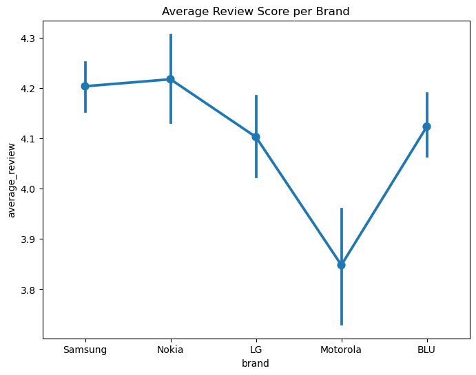

```python
plt.figure(figsize=(8, 6))
sns.pointplot(x='brand', y='average_review', data=asin_review_brand, errorbar=('ci', 95))
plt.title('Average Review Score per Brand')
plt.show()
```

```python
# plt.figure(figsize=(10, 5))
# sns.lineplot(x='brand', y='average_review', data=asin_review_brand, marker='o', label='Average review per brand')
# plt.fill_between(asin_review_brand['brand'], confidence_interval[0][:len(asin_review_brand)],
# plt.title('Average review per brand with CI portrayed as green.')
# plt.show()
```

(δεν μου έβγαιναν με for)

```python
brands = asin_review_brand['brand'].unique()
for i in range(len(brands)):
    for j in range(i+1, len(brands)):
        brand1 = asin_review_brand[asin_review_brand['brand'] == brands[i]]['average_review']
        brand2 = asin_review_brand[asin_review_brand['brand'] == brands[j]]['average_review']
        t_stat, p_val = ttest_ind(brand1, brand2)
        print(f" {brands[i]} RELATIONSHIP {brands[j]} -> t-STATISTIC VALUE  = {t_stat}\n , p-VALUE = {p_val}\n\n \n")
```

```
 Samsung RELATIONSHIP Nokia -> t-STATISTIC VALUE  = -0.280901780335475
 , p-VALUE = 0.7789083049537942



 Samsung RELATIONSHIP LG -> t-STATISTIC VALUE  = 2.176663185317431
 , p-VALUE = 0.029956623294456832



 Samsung RELATIONSHIP Motorola -> t-STATISTIC VALUE  = 6.586763012812294
 , p-VALUE = 1.1993637243518487e-10



 Samsung RELATIONSHIP BLU -> t-STATISTIC VALUE  = 1.9499424431928416
 , p-VALUE = 0.05170009829633629



 Nokia RELATIONSHIP LG -> t-STATISTIC VALUE  = 1.8787049831875615
 , p-VALUE = 0.06133867967065514



 Nokia RELATIONSHIP Motorola -> t-STATISTIC VALUE  = 5.236165700960336
 , p-VALUE = 3.6840811693036283e-07



 Nokia RELATIONSHIP BLU -> t-STATISTIC VALUE  = 1.817096529533689
 , p-VALUE = 0.07020666767551002



 LG RELATIONSHIP Motorola -> t-STATISTIC VALUE  = 3.6953746628059143
 , p-VALUE = 0.0002649184285278083



 LG RELATIONSHIP BLU -> t-STATISTIC VALUE  = -0.3978183417475417
 , p-VALUE = 0.6910122937530214



 Motorola RELATIONSHIP BLU -> t-STATISTIC VALUE  = -4.601618967796183
 , p-VALUE = 6.2179521354006814e-06
```

## ΕΡΏΤΗΜΑ 3Ε

review quality

```python
review_quality.head()
```

|  | overall | verified | reviewTime | reviewerID | asin | style | reviewerName | reviewText | summary | unixReviewTime | vote | image |
| --- | --- | --- | --- | --- | --- | --- | --- | --- | --- | --- | --- | --- |
| 0 | 5 | True | 08 4, 2014 | A24E3SXTC62LJI | 7508492919 | {'Color:': ' Bling'} | Claudia Valdivia | Looks even better in person. Be careful to not... | Can't stop won't stop looking at it | 1407110400 | NaN | NaN |
| 1 | 5 | True | 02 12, 2014 | A269FLZCB4GIPV | 7508492919 | NaN | sarah ponce | When you don't want to spend a whole lot of ca... | 1 | 1392163200 | NaN | NaN |
| 2 | 3 | True | 02 8, 2014 | AB6CHQWHZW4TV | 7508492919 | NaN | Kai | so the case came on time, i love the design. I... | Its okay | 1391817600 | NaN | NaN |
| 3 | 2 | True | 02 4, 2014 | A1M117A53LEI8 | 7508492919 | NaN | Sharon Williams | DON'T CARE FOR IT. GAVE IT AS A GIFT AND THEY... | CASE | 1391472000 | NaN | NaN |
| 4 | 4 | True | 02 3, 2014 | A272DUT8M88ZS8 | 7508492919 | NaN | Bella Rodriguez | I liked it because it was cute, but the studs ... | Cute! | 1391385600 | NaN | NaN |

```python
review_quality['vote'] = review_quality['vote'].replace(0, np.nan)
review_quality = review_quality.dropna(subset=['vote'])
review_quality.head(20)
```

|  | overall | verified | reviewTime | reviewerID | asin | style | reviewerName | reviewText | summary | unixReviewTime | vote | image |
| --- | --- | --- | --- | --- | --- | --- | --- | --- | --- | --- | --- | --- |
| 32 | 5 | True | 02 18, 2013 | A2KCKROPJ72AE3 | 7508492919 | NaN | Doni Washburn | Ive never had any problems with anything ... i... | good | 1361145600 | 2 | NaN |
| 72 | 1 | False | 02 16, 2011 | A3U2VAZBCBU7K6 | 7532385086 | NaN | cb6 | I was very excited when I first got this case.... | A waste of money! | 1297814400 | 9 | NaN |
| 97 | 5 | True | 12 11, 2013 | A1AGQVCNRY2G8G | 8288853439 | NaN | MDB | This Charger is awesome! First of all I wasn't... | Galaxy S4 Charger | 1386720000 | 4 | NaN |
| 192 | 5 | True | 08 5, 2013 | A2BTI59ON0XQDC | 8288878881 | NaN | Martha Cordero | Received it promptly and it worked perfectly f... | Quick and perfect! | 1375660800 | 8 | NaN |
| 199 | 1 | True | 04 14, 2013 | A1A2GP9SM4GCPD | 8288878881 | NaN | CRH | Although it does charge, albeit slower than my... | It charges, but it doesn't sync with my laptop | 1365897600 | 3 | NaN |
| 201 | 1 | True | 04 10, 2013 | A3D1F28RDA23QA | 8288878881 | NaN | Tall Paul | In a nutshell, this is NOT an OEM charger. Al... | Not as nice as I thought it would be | 1365552000 | 2 | NaN |
| 211 | 5 | True | 10 16, 2012 | ALOJ76ILLNTWE | 8288878881 | NaN | Pedro | I just wanted a charger like the original one ... | Works as expected | 1350345600 | 19 | NaN |
| 237 | 5 | True | 06 8, 2014 | A3JD13BMG9N33C | 961301375X | {'Color:': ' White'} | Autumn | it works and the cool blue light is neat and h... | it works and it looks cool too | 1402185600 | 3 | NaN |
| 240 | 4 | True | 04 30, 2014 | A17EZ2V5C4D4AI | 961301375X | {'Color:': ' White'} | keith | sorry i'm not super exited, it is just a "phon... | seems good. | 1398816000 | 2 | NaN |
| 242 | 5 | False | 02 6, 2015 | ANMATY0L0HX6Y | 9638762632 | NaN | Sasha Malkin | Great Item,\n\nI have an s3, its an old phone ... | Thanks Guys | 1423180800 | 10 | NaN |
| 248 | 4 | True | 10 31, 2015 | A2ZPJYFQ5OVOD7 | 9638762632 | NaN | Leo Allen | Works exactly as described. The directions tha... | Exactly As Described | 1446249600 | 9 | NaN |
| 249 | 5 | True | 10 12, 2015 | AHMRKS7TFV645 | 9638762632 | NaN | Salah Hawsawi | Very good | Five Stars | 1444608000 | 9 | [https://images-na.ssl-images-amazon.com/image... |
| 251 | 4 | True | 09 27, 2015 | A1BTNG8EH2SANW | 9638762632 | NaN | j0n | it does what it promises. normally I'd start c... | decent case | 1443312000 | 7 | NaN |
| 254 | 5 | True | 05 11, 2015 | A19S8EQ420G6S6 | 9638762632 | NaN | Nora Caraballo | Nice | Five Stars | 1431302400 | 3 | NaN |
| 265 | 3 | True | 06 2, 2014 | A3UJ01JHVNE3EC | 9658231969 | NaN | Chris B | So I have been using this item for a few weeks... | Works Great! | 1401667200 | 3 | NaN |
| 266 | 3 | True | 05 7, 2014 | A3H5NB3SUVKKRU | 9658231969 | NaN | Isaac | Feels good and all, but the charging is too sl... | Slow charge. | 1399420800 | 2 | NaN |
| 268 | 5 | False | 09 8, 2014 | ANMATY0L0HX6Y | 9678315173 | NaN | Sasha Malkin | Great Product, Looks sleek and lasts for 3 day... | Very Nice | 1410134400 | 7 | NaN |
| 271 | 4 | True | 09 22, 2015 | A3OZYC2GCCYHL1 | 9678315173 | NaN | Zona_G | I bought this case for my mother's phone so th... | Nice case, suits my Mom's needs perfectly. | 1442880000 | 2 | NaN |
| 272 | 5 | True | 03 7, 2015 | A22HWUG553W828 | 9678315173 | NaN | Jed Lack | I bought 2 of these to go on my children's pho... | I love them because the "I had a dead battery"... | 1425686400 | 10 | NaN |
| 273 | 4 | True | 03 4, 2015 | A2YQPYDGSKRYB7 | 9678315173 | NaN | Bob H. | Nice product but it recharge is not as strong ... | OK Not as good as my old Mophie ... Sorry Powe... | 1425427200 | 4 | NaN |

```python
review_quality['reviewText'] = review_quality['reviewText'].replace(0, np.nan)
review_quality = review_quality.dropna(subset=['reviewText'])
review_quality['lengthRev'] = review_quality['reviewText'].apply(len)








#############--------------------------------------------------------------------------########




#first drop columns
#review_quality = review_quality.drop(columns=['asin', 'overall', 'summary', 'unixReviewTime', 'reviewTime'])
#review_quality = review_quality.drop(columns=['reviewerID', 'reviewerName', 'style', 'image'])
#review_quality = review_quality.drop(columns=['verified'])
```

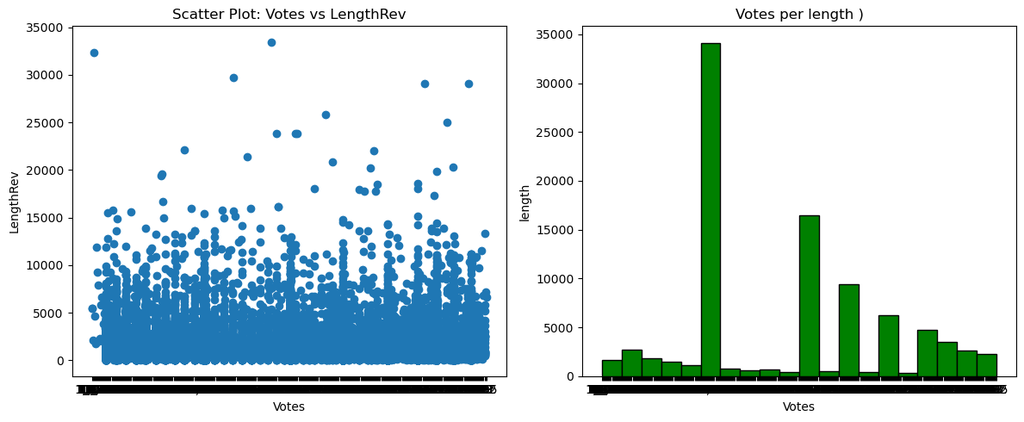

```python
review_quality_sorted = review_quality.sort_values(by='vote')

# Scatter plot
plt.figure(figsize=(12, 5))
plt.subplot(1, 2, 1)
plt.scatter(review_quality_sorted['vote'], review_quality_sorted['lengthRev'], marker='o')
plt.xlabel('Votes')
plt.ylabel('LengthRev')
plt.title('Scatter Plot: Votes vs LengthRev')
plt.subplot(1, 2, 2)
plt.hist(review_quality_sorted['vote'], bins=20, color='green', edgecolor='black')
plt.xlabel('Votes')
plt.ylabel('length')
plt.title('Votes per length )')

plt.tight_layout()
plt.show()
```

[figure not shown]

```python
# Scatter plot
plt.scatter(review_quality_sorted['lengthRev'], review_quality['vote'])
plt.xlabel('Log(Vote)')
plt.ylabel('length')
plt.title('Log(Vote) - length')
plt.show()
```

```python
print(review_quality['vote'].dtype)
review_quality['vote'] = pd.to_numeric(review_quality['vote'], errors='coerce')

print(review_quality['vote'].dtype)
```

```
object
float64
```

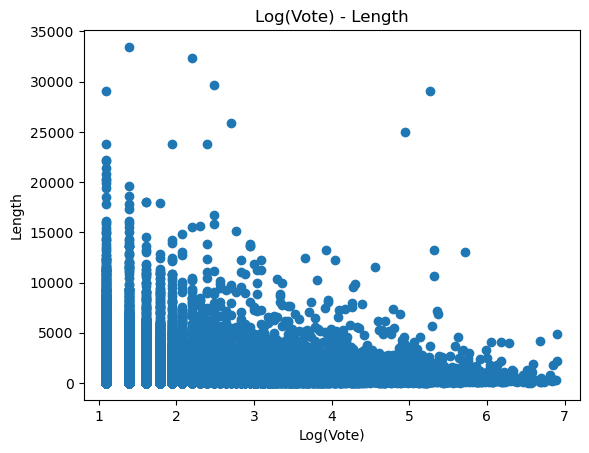

```python
log_vote = np.log1p(review_quality['vote'])
plt.scatter(log_vote, review_quality_sorted['lengthRev'])
plt.xlabel('Log(Vote)')
plt.ylabel('Length')
plt.title('Log(Vote) - Length')
plt.show()
```

Αναλύωντας βλέπουμε ότι υπάρχει μια μικρή συσχέτηση ανάλογα με τις λέξεις και τα votes δηλαδή την ποιότητα των reviews. Ωστόσο δεν ειναι αξιοσημείωτη και από ότι δείχνουν τα διαγράμματα, η χρησιμότητα των reviews δεν κρύβεται στο μέγεθος τους.

## ΕΡΩΤΗΜΑ 3 z

```python
review_quality2.head()
```

|  | overall | verified | reviewTime | reviewerID | asin | style | reviewerName | reviewText | summary | unixReviewTime | vote | image |
| --- | --- | --- | --- | --- | --- | --- | --- | --- | --- | --- | --- | --- |
| 0 | 5 | True | 08 4, 2014 | A24E3SXTC62LJI | 7508492919 | {'Color:': ' Bling'} | Claudia Valdivia | Looks even better in person. Be careful to not... | Can't stop won't stop looking at it | 1407110400 | NaN | NaN |
| 1 | 5 | True | 02 12, 2014 | A269FLZCB4GIPV | 7508492919 | NaN | sarah ponce | When you don't want to spend a whole lot of ca... | 1 | 1392163200 | NaN | NaN |
| 2 | 3 | True | 02 8, 2014 | AB6CHQWHZW4TV | 7508492919 | NaN | Kai | so the case came on time, i love the design. I... | Its okay | 1391817600 | NaN | NaN |
| 3 | 2 | True | 02 4, 2014 | A1M117A53LEI8 | 7508492919 | NaN | Sharon Williams | DON'T CARE FOR IT. GAVE IT AS A GIFT AND THEY... | CASE | 1391472000 | NaN | NaN |
| 4 | 4 | True | 02 3, 2014 | A272DUT8M88ZS8 | 7508492919 | NaN | Bella Rodriguez | I liked it because it was cute, but the studs ... | Cute! | 1391385600 | NaN | NaN |

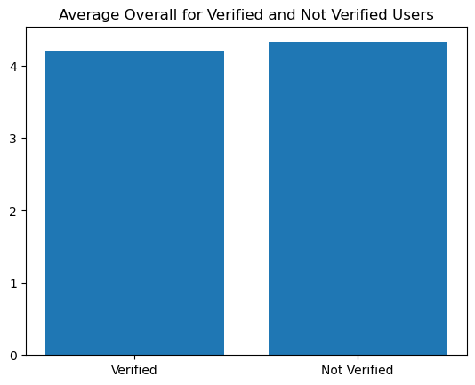

```python
review_quality2 = review_quality2.dropna(subset=['overall'])
review_quality2 = review_quality2[review_quality2['overall'] >= 1]
average_overall_verified = review_quality2.loc[review_quality2['verified'] == True, 'overall'].mean()
average_overall_not_verified = review_quality2.loc[review_quality2['verified'] == False, 'overall'].mean()
plt.bar(['Verified', 'Not Verified'], [average_overall_verified, average_overall_not_verified])
plt.title('Average Overall for Verified and Not Verified Users')

plt.show()
```

Δεν υπάρχει διαφορά για verified kai non verified.

## ΕΡΩΤΗΜΑ 3 H

```python
review_quality1.head()
```

|  | overall | verified | reviewTime | reviewerID | asin | style | reviewerName | reviewText | summary | unixReviewTime | vote | image |
| --- | --- | --- | --- | --- | --- | --- | --- | --- | --- | --- | --- | --- |
| 0 | 5 | True | 08 4, 2014 | A24E3SXTC62LJI | 7508492919 | {'Color:': ' Bling'} | Claudia Valdivia | Looks even better in person. Be careful to not... | Can't stop won't stop looking at it | 1407110400 | NaN | NaN |
| 1 | 5 | True | 02 12, 2014 | A269FLZCB4GIPV | 7508492919 | NaN | sarah ponce | When you don't want to spend a whole lot of ca... | 1 | 1392163200 | NaN | NaN |
| 2 | 3 | True | 02 8, 2014 | AB6CHQWHZW4TV | 7508492919 | NaN | Kai | so the case came on time, i love the design. I... | Its okay | 1391817600 | NaN | NaN |
| 3 | 2 | True | 02 4, 2014 | A1M117A53LEI8 | 7508492919 | NaN | Sharon Williams | DON'T CARE FOR IT. GAVE IT AS A GIFT AND THEY... | CASE | 1391472000 | NaN | NaN |
| 4 | 4 | True | 02 3, 2014 | A272DUT8M88ZS8 | 7508492919 | NaN | Bella Rodriguez | I liked it because it was cute, but the studs ... | Cute! | 1391385600 | NaN | NaN |

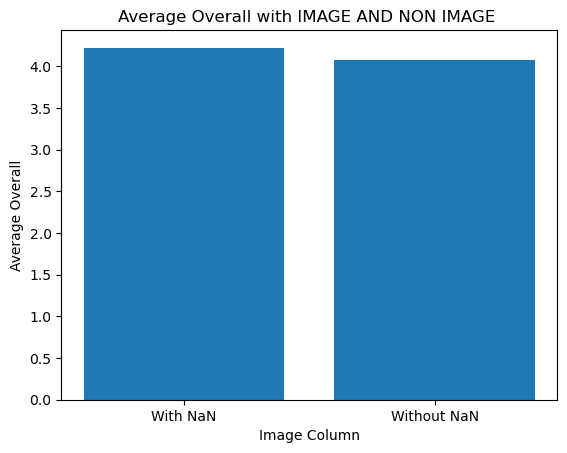

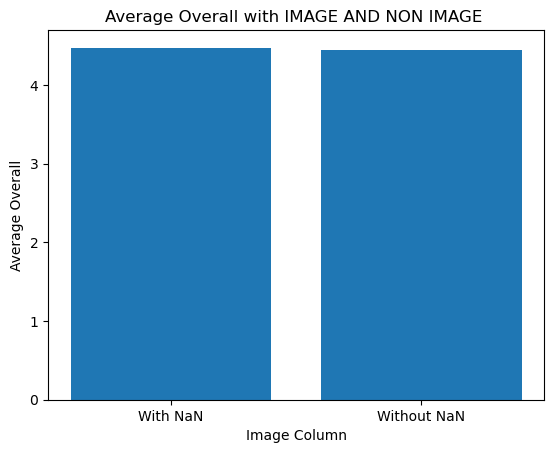

```python
average_overall_with_nan = review_quality1.loc[review_quality1['image'].isna(), 'overall'].mean()
average_overall_without_nan = review_quality1.loc[~review_quality1['image'].isna(), 'overall'].mean()
plt.bar(['With NaN', 'Without NaN'], [average_overall_with_nan, average_overall_without_nan])

plt.xlabel('Image Column')
plt.ylabel('Average Overall')
plt.title('Average Overall with IMAGE AND NON IMAGE ')
plt.show()

review_quality1 = review_quality1[review_quality1['overall'] >= 2]

average_overall_with_nan = review_quality1.loc[review_quality1['image'].isna(), 'overall'].mean()
average_overall_without_nan = review_quality1.loc[~review_quality1['image'].isna(), 'overall'].mean()
plt.bar(['With NaN', 'Without NaN'], [average_overall_with_nan, average_overall_without_nan])

plt.xlabel('Image Column')
plt.ylabel('Average Overall')
plt.title('Average Overall with IMAGE AND NON IMAGE ')
plt.show()
```

Δεν έχει σημασία αν υπάρχει εικόνα στο review για το πόσο βοηθητικό είναι για το κοινό καθώς αν αφαιρέσουμε τα τελείως αρνητικά review η στήλες είναι παρόμοιες.